# Saudi Arabia Grand Prix Fantasy League Report

sabah alkhayr ya mudirin and welcome to the race report for the 2025 Formula 1 Saudi Arabian Grand Prix, and the accompanying Fantasy League report, of course. The Saudi Grand Prix has been on the calendar since 2021, launched initially to form a double-header Middle East finally, it has since found its place at the start of the calendar, alongside the Bahrain Grand Prix. The Jeddah Corniche circuit is the fastest street circuit in Formula 1, but also the third longest behind Spa and Vegas. It has evolved over the years, gone are the tight walls in the high-speed sections, to allow for visibility and an increase in overall driver safety. We certainly got lucky that no one was seriously injured in the early days, and the track has really become quite the fan favourite. Every single Saudi Arabian Grand Prix has seen the deployment of a safety car, and I think I'm right in saying that every Grand Prix there has been an absolute banger. 2021 saw the duel between championship rivals Lewis Hamilton and Max Verstappen, with the famous overtake into the last corner that Sky like to play in slow-mo any chance they get. 2022 was the duel between Max and Charles, playing DRS games and giving us hope that the new regulations would save us. 2023 was a fight between the Red Bulls, ultimately won by Sergio Perez, where the two pushed the boundaries of the circuit and their relationship. 2024 was a chaotic race, seeing the arrival of Oliver Bearman, the fight between Lando Norris and Lewis Hamilton, and a lesson in "taking one for the team" from Kevin Magnussen. So lots to live up to this year for the Jeddah circuit. Let's get into it.

## The News

There wasn't an awful lot of new between the Bahrain and Saudi Grand Prix, since it was only a week, but there are a few key areas I'd like to focus on.

### Verstappen's Future

It wouldn't be an era following a world champion domination without speculation that the partnership between the champion and the team that took him there might be coming to an end. Honestly, I didn't expect it to happen this early in the season, but Max has always been early to these career moments. In case you didn't know, Max Verstappen has a contract with Red Bull until the end of 2028, part of an extension he signed in 2022 to take him into another regulation era. There exists, however, a cancellation clause based on team/driver performance, whereby Max can break his contract if key figures depart the team or if the team fail to perform. It is my understanding that this performance clause is lower than third in the championship. Since Max is currently in third, and has Russell close for company, the rumours started circling the paddock this week that other teams were making him offers. Obviously, a driver of his caliber is going to get offers all the time, and we have seen how easy it can be for a contract to be broken, but for these to make it into the public eye, they must have some substance. Max has, reportedly, also received an offer from McLaren in recent years, with his PR team reporting that Zak could not afford the contract. This time, it's Aston Martin and Mercedes who are rumoured to have been in touch with Max regarding a drive in 2026. But why? Well George Russell's contract is up at the end of the year, but the two Astons are signed on for a while, it is probably the tie to Adrian Newey that is leading the charge behind the Aston Martin rumours.

Regardless, Max moved to shut down the rumours quickly in the pre-race weekend press conference, stating that "A lot of people are talking about it except me. I just want to focus on my car, work with the people in the team - that's the only thing I'm thinking about in Formula 1 at the moment". What was quite bold is that the media assumed that it would be Lance that would move aside to let the reigning champion drive in green next year, with Alonso asked if he would like to have Max as a teammate. When one reported did ask if Alonso was worried he might be out of a job next year, the double-world champion responded with "I don't think so, as I have a contract for next year". The Spaniard came out and let slip that while his driving contract is for 2 years, his contract with Aston Martin extends beyond that of his driving career, with Alonso linked to an advisory role with the Silverstone-based team post-racing career. He's not the only world champion linked to a driver training program, with Helmut Marko naming Sebastian Vettel as the person he would like to see takeover the Red Bull academy when he retires. While Russell might be out of a contract for next year, boss Toto Wolff is looking to extend the Brit before the summer break when both parties know better the position they are in. Russell is doing himself a massive favour in that regard putting in consistent results and challenging for the top three in the standings. What do you think? Could we see a big career-altering move from the Dutchman this year? Or is this just a blip in an otherwise bullet-proof performance by the partnership?

### Sainz Maturing

Carlos Sainz isn't exactly a stranger to the chaos that is the F1 midfield, the Spaniard came into F1 with Toro Rosso, before moving through Renault, McLaren, and into Ferrari before this season. He has spent a lot of his racing career in the scrappy, almost-desperate battles that exist in that part of the grid, where points are few and far between. More recently, namely during his Ferrari days, Carlos enjoyed battling at the front, where moves are more measured as there's a lot more at stake. Since his move to Williams, however, Carlos has found himself on the verge of the top ten, battling with drivers who will give anything to score a handful of points because it means so much to them and the team. A situation he hasn't really found himself in since 2020. After a mixed start to the season, the Spaniard found himself battling with Yuki Tsunoda in a Red Bull at the Bahrain Grand Prix, where the two made contact. Most of the blame was given to Tsunoda, who slid into the overtake and took a huge chunk out of the Williams sidepod. Carlos came out this week to say that his new reality may require a different approach to his previous style, he said "I'm gutted that we didn't manage to capitalize on points. Looking back at it, maybe with a bit of time, nothing could have been different with what I did with Yuki losing the rear and hitting my car, but just maybe picking my rights a bit better". He went on to say that perhaps he needs to get out of this mindset of fighting with the top three or four teams, and focus his attention on the teams that are looking to take points from the Williams team, as they are fighting on the verge of being the fifth best team. Sainz, like many of the drivers, has a very self-critical approach, and this shows a real sign of maturing as a driver.

### Piastri On Form

Oscar Piastri became the first multiple-race winner at the Bahrain Grand Prix and is catching up the deficit to teammate Lando Norris and reigning champion Max Verstappen, caused by his little spin into the grass in Australia. Oscar is a relative rookie compared to the two ahead of him in the standings, only entering his third season in F1 for the 2025 season. Piastri had the perfect weekend in Bahrain, securing pole position and leading nearly every lap of the Grand Prix to cross the line first, significantly ahead of George Russell, despite a late-race safety car. There's no doubt that the McLaren is one of the fastest cars on the grid, if not the fastest car on the grid, at the moment; but that doesn't detract from the stellar performance that the young Aussie is putting in at the moment. Team boss Andrea Stella said after the race that the victory was "Very meaningful. First victory in Bahrain which is our second home Grand Prix", he's referring to their shareholders, but the point stands. McLaren haven't even been on the podium in Bahrain since 2010. Stella is not the only one full of praise for Oscar, manager Mark Webber believes he has "Stepped up his game against the serious artillery of his rivals". Webber knows a thing or two about being the underdog in a team, after spending many years playing second-fiddle to Sebastian Vettel at Red Bull, and it's likely that with Mark in his corner, Oscar could go on to win the championship this season, despite the desire in McLaren for Lando to be their title hope.

## Grand Prix Report

Pierre Gasly topped FP1, which must have come as quite a surprise to him and the team. Though with Saudi being a night race, and FP1 taking part during the day, most teams were not turned up to the max to set the world alight. Still, nice to see Gasly's name at the top of the timing tower. In FP2, Yuki Tsunoda decided to recreate the infamous Max Verstappen crash at the final corner. The incident was almost exactly the same, though Yuki did turn in slightly too early and clipped the inside wall, where Max ran wide during what could have been the best F1 qualifying lap of all time, so the stakes were a lot less. Nevertheless, Yuki bounced back in confidence in time for FP3.

### Qualifying Report

With three of the four races at Saudi being won from pole position, and all of the races in 2025 being won from pole, qualifying in Saudi Arabia is certainly a very important session. The McLarens came out in Q1 punching, with Oscar just pipping Lando in the early stages. Meanwhile, the two Haas drivers, Lance Stroll, Sainz, and Bortoleto were the drivers in trouble halfway through the session, sitting in the bottom five. Bortoleto had had a fuel leak in FP2 and had therefore missed all of the representative running under the lights. As the chequered flag flew, however, it looked like the Ferrari boys might have been in trouble; Lewis managed to rescue his lap right at the very end, and Leclerc was lucky not to be eliminated, dropping down to 13th place. The usual suspects were eliminated in the first part of qualifying, those being: Lance Stroll, Jack Doohan, Nico Hulkenberg, Esteban Ocon, and Gabriel Bortoleto.

It was Verstappen who topped the early timing charts in Q2, the Dutchman putting in that extra bit when it's needed to pip Norris at the top. There were plenty of laps deleted throughout qualifying due to track limits, but Lawson had a good lap deleted in Q2 dropping him down to the elimination zone with only a few minutes left on the clock. No mistakes from the top four teams though, Ferrari, McLaren, Red Bull, and Mercedes had both their drivers occupying the top spots, so that meant the fight for those last two places was pretty tight. It was all about who still had new tyres to throw at the session, and that just so happened to be Pierre Gasly and Carlos Sainz, who just made it through at the expense of his teammate. Drivers eliminated in Q2 were: Alex Albon, Liam Lawson, Fernando Alonso, Isack Hadjar, and Ollie Bearman.

So with McLaren and Max trading times at the top of the table, and qualifying expert Charles Leclerc all entering Q3, who was going to take pole? Piastri put in the first lap time to beat, going out early, but as the others joined him in their first runs, our attention turned to a red flag situation. Lando Norris got up on the kerbs on the outside of turn 4, lost control and collided with the opposite wall in turn 5. He confirmed he was ok, but called himself an idiot over the radio too, probably by accident. The Brit had yet to set a lap time and thus would start tenth, throwing away any chance he had at fighting for victory this weekend. There was a question over the broadcast about whether Oscar's lap time would stand because the commentators had no idea where the timing line was. This theme continued throughout the weekend, and it's very disappointing to see that the people we have guiding us through this sport, still have no idea what they're doing. Replays showed that Oscar had indeed crossed the timing line, but not the start line when the red flag was thrown, and thus his lap stood. When the green flag flew, Verstappen went out and beat Piastri's lap by 0.001 second, the Dutchman having enough time on the board for a second run, while the others all waited in the pits. Russell went to the top before Max and Oscar had chance to set their laps, the Aussie crossed the line to displace him, but Max was flying. The reigning champ grabbed pole position to everyone's amazement, given the pace the papaya machine has. He beat Piastri by 0.01 seconds in the end. Behind them was Russell, Leclerc, Antonelli, Sainz, Hamilton, Tsunoda, Gasly, and the stricken Norris rounded out the top ten.

### Race Report

So Verstappen on pole, Piastri second, and the Mercedes and Ferraris chasing behind. Who was going to take victory under the lights? Well, we usually expect some chaos at Saudi, and while the race was quite tense and exciting in parts, it was relatively dull. Most of the action happened in the opening few laps. The real drama, in fact, happened at the very first corner. Oscar got a better start on the inside of Max down to turn 1, and just managed to sneak ahead at the apex of turn 1. Max, being Max, tried to run it around the outside, but was never going to make turn 1, so bailed out across the run-off and maintained the lead he had down to turn 1 by going off-track. What he should have done was give the place back, but he was under the impression that he was ahead at the apex, and that the stewards were not penalizing turn 1 incidents as per the driver briefing. However, the stewards felt he had gained a lasting advantage, which would normally carry a 10-second penalty. Since it was turn 1 lap 1, the stewards were lenient and gave the Red Bull driver a 5-second penalty. This ultimately gave Oscar the advantage in the pit stop phase, and allowed the McLaren driver to take his third victory of the season, and the championship lead, ahead of Max in second place.

Further down the order, on the opening lap, Yuki Tsunoda and Pierre Gasly came together at turn 4. The Frenchman was on the outside into the corner, and just didn't quite leave enough space for Yuki on the inside, who also didn't want to yield. Two-into-one never quite works out, and Yuki clipped the back wheel of the Alpine, sending both of them backwards into the wall on the outside of turn 5. This brought out an early safety car, and caused both drivers to retire early from the race. This did play into the hands of Lando Norris, who probably had the pace to be at the front, and probably should have been on the front row, if not the second. He inherited two places, and had started on the alternate strategy, meaning he could run long into the race and perhaps goal-hang for a late-race safety car. Sadly one didn't arrive, and the Brit spent most of his race battling with the Ferraris. Leclerc had opted to push the mediums a little beyond the optimum window, to give himself a good set of hards to push on at the end of the race. This worked well for him, and he was able to cut back through and take third place ahead of Lando. Lando, on the other hand, struggled to overtake the other Ferrari of Lewis Hamilton, seemingly forgetting they had moved the DRS detection zone for the start/finish straight after 2022, twice, and struggling to use the fresh mediums to gain on Leclerc in the final stint. It was close, but no cigar for the McLaren man.

After saying earlier in the week that he wanted to focus on the midfield fight, rather than waste time defending from the top runners, Carlos Sainz put in a great team performance to bring his Williams home in P8, dragging his teammate along in the DRS to protect from a rapid Isack Hadjar behind. The Spaniard demonstrated the same skill that won him the Singapore Grand Prix in 2023, keeping Alex perfectly in his DRS and preventing the Racing Bull gaining an advantage. A solid double-points finish for Williams is exactly what they needed. So Piastri, Verstappen, Leclerc, Norris, then the two Mercedes, who seemed to struggle for race pace and finished close together on track, followed by Hamilton, the two Williams cars, and Hadjar in tenth. Behind them was Fernando Alonso, who missed out on points yet again in 2025, but put in a decent performance to put that Aston Martin in eleventh, way ahead of where it should be. Lawson was behind him, carrying a ten-second penalty for a weird incident whilst overtaking Jack Doohan down the main straight. The Kiwi driver was ahead by the braking zone, but overran slightly and ran just over the white line on the inside of turn 2, despite already being ahead. The stewards deemed he had left the track and gained an advantage and slapped him with the much harsher penalty than that given to Max.

An uneventful race for the Haas drivers behind them, followed by Nico Hulkenberg, who did a good job to beat Lance Stroll in a much slower car. This after Lance Stroll slammed the Kick Sauber team after qualifying. Yep, that's right, Lance threw his toys out the pram big time after he set the record for the most Q1 eliminations in F1 history on Saturday. The Canadian threw some shade at the Swiss outfit saying "if you put the McLaren drivers in a Sauber, they'll also get eliminated" - I'm paraphrasing there slightly, but that was the gist of what he said. Doohan and Bortoleto had a disappointing but uneventful race to round out the grid, at least they survived unscathed. Interestingly though, Bortoleto had a little bit of an incident with Fernando Alonso into turn 1. The rookie was battling with a car ahead, and didn't check if there was a car on his outside. He left just enough for Alonso to occupy that space, giving the Spaniard, and all of us, quite the scare. Not quite the way you are expected to treat your manager, but it is exactly how a young Alonso would have treated his manager had they been racing at the time.

## Fantasy League Scores

Scores for drivers/constructors in the current year's fantasy league, along with manager/team points, values, and statistics. Note: driver and constructor values are taken as the cost to enter the current race and are updated the week before the race.

## Lineup Scores

This week, the pole sitter and the race winner tied for the top score, Max Verstappen and Oscar Piastri both bring 38 points home from the Saudi Grand Prix ahead of fantasy championship leader Lando Norris who recovered well to score 36 points. Podium finisher Charles Leclerc is in fourth place with 25 points, and Mr consistent, George Russell, rounds out the top five with 16 points. Our DNF drivers were at the bottom this week, both suffering a -17 points haul. Then it's Jack Doohan and Lance Stroll, with a pair of ones, followed by the Kick Sauber duo with a pair of threes. It's two by two, with Lawson and Bearman both getting five points, and Esteban Ocon rounds out the bottom five with 6 points.

McLaren top yet another race weekend, bringing home a very impressive 86 points ahead of Ferrari with 64 and Mercedes with 46. Alpine suffer another negative score at the bottom of the table with -6 points. Kick Sauber are next up with 10 points, followed by Aston Martin with 11 points.

Lando still sits at the top of the championship standings, but he is being chased week in week out by Oscar Piastri and Max Verstappen. The three of them are clear at the top with 195, 162, and 155 points respectively. The two Mercedes drivers, who are quietly going about a good season, round out the top five with 125 points to Russell and 113 points to Antonelli. Fernando Alonso still sits at the bottom of the table with -20 points, though he is slowly recovering that deficit. He's joined by Pierre Gasly who seems to be having a very up-and-down season, he sits on -11 points. Rookie Bortoleto is next with -6 points, behind Carlos Sainz with -4 points. Jack Doohan currently has 0 points to his name, rounding out the bottom five.

McLaren continue to stretch their lead at the top of the standings, with the Woking outfit sitting on 421 points to their name. Mercedes are a comfortable second with 298 points, while Ferrari surge back up the order with an impressive few weeks to third, with 206 points. All the teams now have positive points, with Kick Sauber sitting on 3 at the bottom. They're behind Alpine with 5 points, and Aston Martin are a lonely third with 43 points.

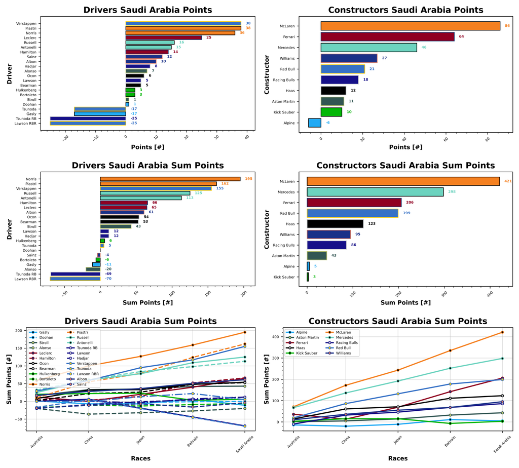

There's a big gulf between the top few drivers and the bottom few drivers in the market at the moment. Lando Norris is sitting on $30, ahead of Max on $28.8. Then it's Leclerc at $24.7, Piastri on $23.4 and Hamilton at $23.2. Bortoleto, on the other hand, was your cheapest option this week, on a mere $4.5. He's joined down there by Hadjar ($5.1), Doohan ($5.6), Alonso ($6.8), and Hulkenberg/Lawson ($7.2).

McLaren was your most expensive constructor this week, with a value of $31.2, ahead of Ferrari at $27.3 and Red Bull at $26. Kick Sauber were your cheapest team this week with $5.4, behind Aston Martin with $7.7 and Alpine with $7.9.

All values are in $M.

Tsunoda, Lawson, and Gasly are currently your worst drivers of the season, only scoring positive points in 2 of the five races so far. There's still a good group of drivers who have scored positively in every race, and probably enough in there to build a team... It's more disappointment for Alpine fans I'm afraid, they are by far the worst performing team of the season, only scoring positive points in 2/5 races. Kick Sauber have managed 1 extra positive race weekend this season. Ferrari and Racing Bulls have only dropped 1 negative score this season.

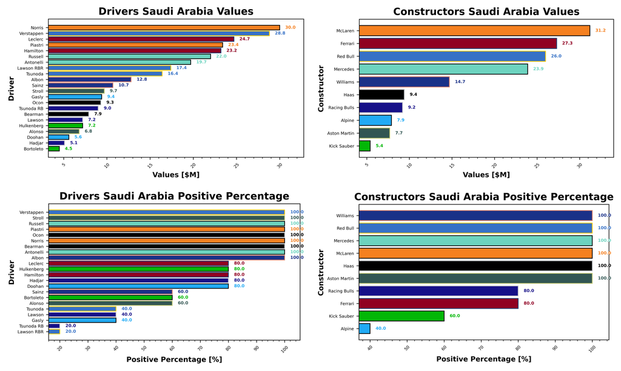

Championship leader, Lando Norris' average points tally is trending downwards as he suffers another average week in the standings. He now sits at 39 points per race. Oscar Piastri is sitting at 32.4 points per race, ahead of Max Verstappen with 31 points per race. George Russell has 25 points per race, ahead of teammate Kimi Antonelli with 22.6 points per race. Fernando is showing signs of improvements lately, he is now averaging a loss of 4 points per race, behind Pierre Gasly with -2.2 points per race. Gabriel Bortoleto next who is pulling in -1.2 points per race behind Carlos Sainz with -0.8 points per race. Jack Doohan has averaged 0 points per race to round out the bottom five.

McLaren are pulling in a whopping 84.2 points per race ahead of Mercedes and Ferrari with 59.6 and 41.2 points per race. Kick Sauber have a miserable 0.6 points per race, followed by Alpine with 1 point per race and Aston Martin with 8.6 points per race.

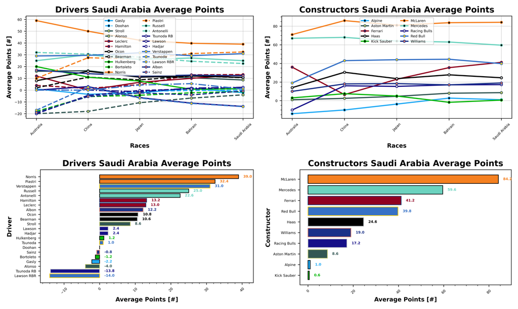

Driver of the week this week is Oscar Piastri, who brought home the victory and 1.62 ppm ahead of Isack Hadjar with 1.57 ppm. Pole sitter Verstappen was in third with 1.32 ppm, followed by title rival Lando Norris with 1.2 ppm. Carlos Sainz rounds out the top three with 1.12 ppm. Somehow Pierre Gasly managed to beat an inactive token this week at the bottom of the table with -1.81 ppm. Yuki Tsunoda was next up with -1.04 ppm, followed by Lance Stroll with 0.1 ppm. Jack Doohan brings home 0.18 ppm, and Nico Hulkenberg rounds out the bottom five with 0.42 ppm.

Team of the week this week was McLaren, who brought in 2.76 ppm ahead of Ferrari in second with 2.34 ppm. Racing Bulls round out the top three with 1.96 ppm. Alpine are the only negative team this week with -0.76 ppm, followed by Red Bull with 0.81 ppm. Haas go from team of the week to bottom three this week with 1.28 ppm.

ppm = points per million ($).

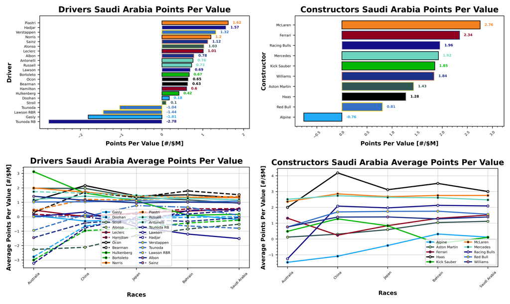

### Manager Scores

Our weekly winner from Saudi Arabia is rookie manager Alfie and Corona Wing Corn with 310 points thanks to a well timed limitless token. They're followed by Stefanus who makes a return towards the top with Syahrul and Haryanto in second and third with 225 points and 207 points. In fourth place it's Josh with Expensify APX GP with 201 points. Rounding out the top five this week we have Patrick and Pete, with their teams You Hadjar Chance Racing and Monaco Barrier Testers both pulling in 200 points.

In a bold move, Alfie pulled off the first extra DRS of the season with their team Cucumberpotatolamborghini to score -42 points this week. In second it's Stuart with Taylormade To Lose with 7. Valerie is next with Perez For World Champion and Stroll To The 18th brining in 38 points. In fourth it's Pete with Seagiant F1 Online and 39 points. Then we have a three-way tie for the final bottom five, it's Valerie, Will, and Patrick, with their teams What Arrrgh Ya Doohan, The Big One, and Coming In Haast Place all scoring 43 points.

Stefanus is at the top of the managers' table for another week this week with 207.33 points. They're followed by Josh with 176.67 points, and then it's Val with 170.67 points. Our worst manager of the week is Valerie with 39.67 points, followed by Stuart with 79 and Will with 101.67 points.

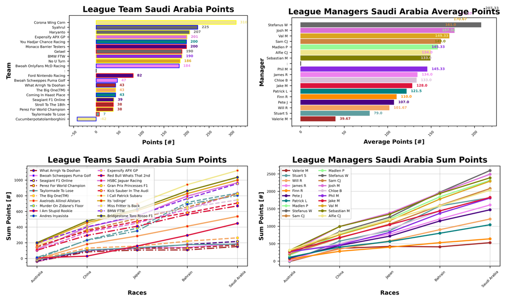

Alfie holds on to their lead at the top with I Call Patrick Subaru, now sitting clear with 1122 points ahead of Sebastian and Bridgestone Toro Rosso F1 with 1036 points. Val is in third place with Its "odinge" coming in at 1000 points ahead of Josh in fourth with HSBC Jaguar Racing and 966 points. Phil and Stefanus round out the top five with BMW FTW and Haryanto, both sitting on 954 points.

Alfie bookends the entire field, with their team Cucumberpotatolamborghini now sitting in last place with 27 points ahead of Valerie with What Arrrgh Ya Doohan and Perez For World Champion with 152 and 171 points, respectively. Stuart is in fourth with Taylormade To Lose with 183 points, and James rounds out the bottom five with Bwoah Schweppes Puma Golf and 189 points.

Our biggest winner this week is Alfie and Corona Wing Corn, jumping up 10 places this week. Then It's Patrick and Pete with their teams You Hadjar Chance Racing and Monaco Barrier Testers who jump 4 places. Stefanus, Chloe, and Josh take a tied third place with Syahrul, Mickeys Roadster Racers, and Expensify APX GP gaining 3 places. Our biggest loser of the week is Chloe and Miss Fritter Is Back dropping 7 places this week. Then it's Stuart and Andres Inyasista losing 6 places.

Stefanus assumes the lead in the average manager points for the season, pushing up to 865.67 points, ahead of Josh and Sebastian with 830 and 796 points. Our worst manager of the season so far is Valerie, scoring 176.33 points this season so far. Will is next with 402.33 points, followed by pete with 490.67.

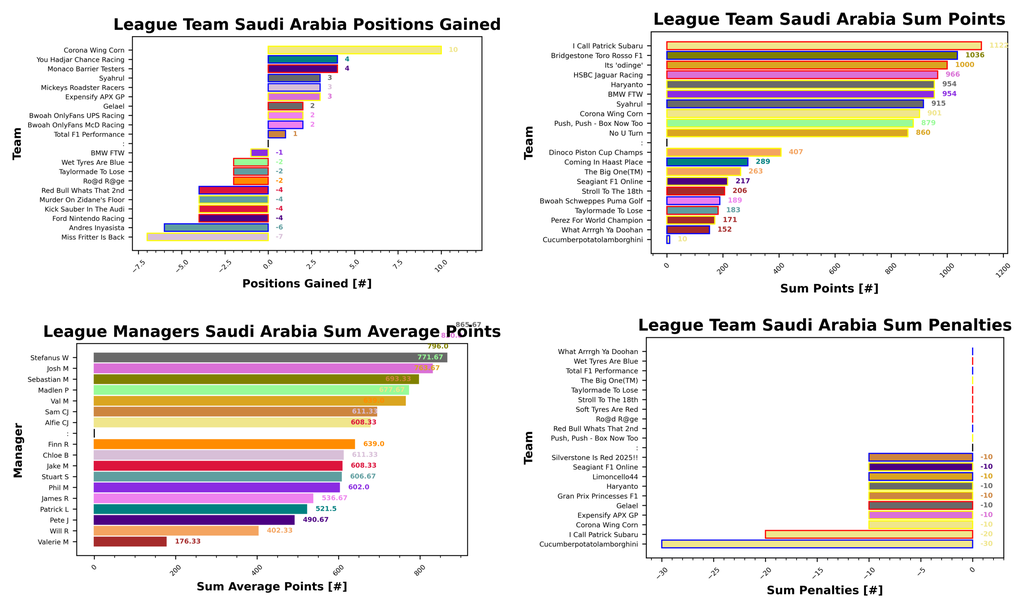

Isack Hadjar is definitely flavour of the month, now appearing in 35 of your teams. He's by far the favourite, as the two Haas boys are next, Bearman with 25 selections and Ocon with 20. Then it's Oscar Piastri who made it into 19 of your teams, and Gabriel Bortoleto who makes 17 selections. Lawson's RBR token is still kicking around in Alfie's team, followed by Hamilton, Tsunoda's RB token, and Verstappen, who make 3 selections. Lawson is in third with 5 selections, followed by Tsunoda, Leclerc, and Antonelli with 6 selections. Fernando Alonso, despite being the lowest scoring driver of the season rounds out the bottom five with 7 selections.

Haas make 20 selections this week, and are the most popular ahead of McLaren with 17 and Kick Sauber with 14. Red Bull are your least used team in Saudi, with only 4 of you choosing the former champions. Alpine and Williams are next with 5 selections each, followed by Racing Bulls and Aston Martin with 6 selections.

Oscar Piastri makes it 16 DRS boost selections this week, with 3 more of you choosing the new championship leader. Norris is in second with 8, and Gabriel Bortoleto makes it 7 to take third. We have finally had an Extra DRS token used, and the honour goes to Liam Lawson's Red Bull token, with just 1 at the top of the table. We had 1 wildcard, 1 limitless, and 1 extra DRS token used this week.

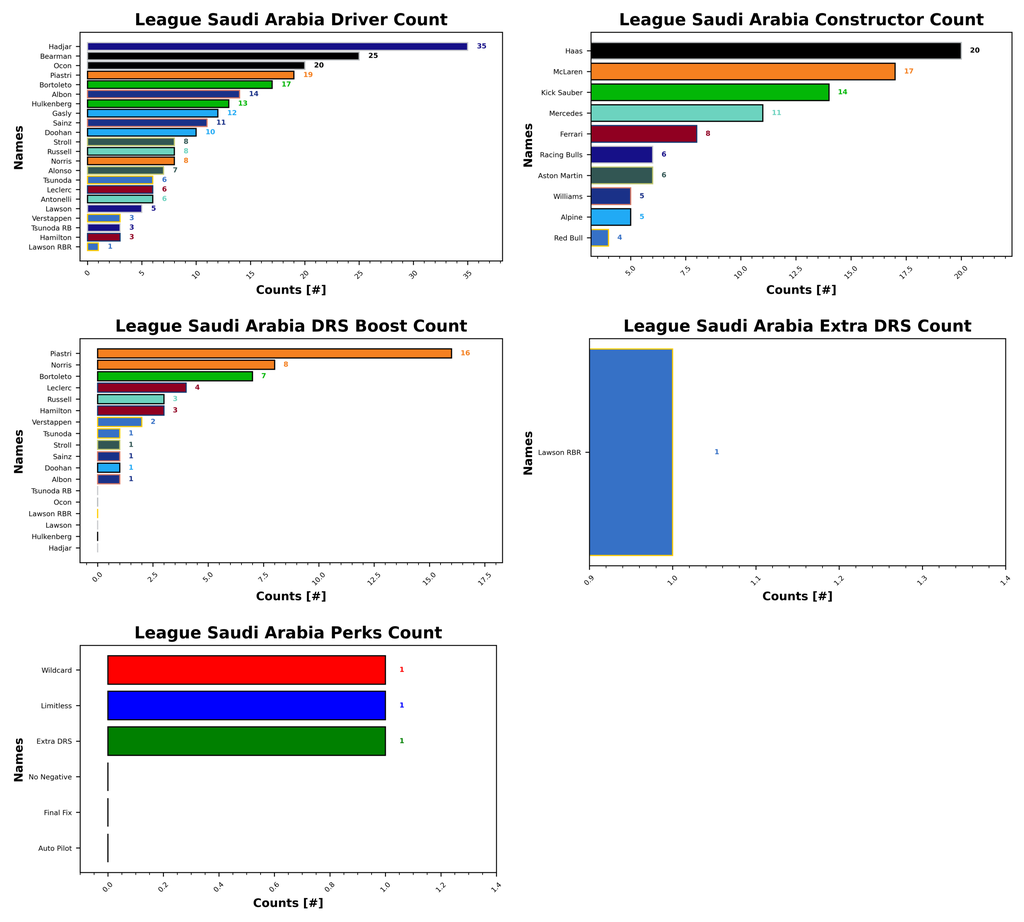

## Prizes

I have now updated the prizes plotting for my code and we should be able to track the season long prizes with ease. So without further adieu, let's take a look at what is currently in play this season.

### Championship

| Prize Name | Prize Value | Terms |
| --- | --- | --- |
|  | (%) |  |
| Champion of the World | 20 | Awarded to the top scorer in the league at the end of the season |
| If You're Not First, You're Last | 10 | Awarded to the second place scorer in the league at the end of the season |
| Alpine Podium | 5 | Awarded to the third place scorer in the league at the end of the season |
| Above Par | 20 | Awarded to the lowest scorer in the league at the end of the season, commonly referred to as the Golf League |

### Achievements

| Prize Name | Prize Value | Terms |
| --- | --- | --- |
|  | (%) |  |
| Cost Cappen | 5 | Highest average points per value at the end of the season |
| Sprint King | 5 | Highest score across the sprint races (China, Miami, Belgium, United States, Brazil, Qatar) |
| Flavio Controls Every Millimeter | 5 | Manager wide substitution count, highest wins |
| The Triple Header | 5 | Highest score across the triple header races (Japan, Bahrain, Saudi Arabia, Emilia Romagna, Monaco, Spain, Las Vegas, Qatar, Abu Dhabi) |
| I Forgot I Was Taking Part | 5 | Highest score in the first part of the season |
| Zak's Master Plan | 5 | Lowest score in the second half of the season |
| Mega Driver | 5 | Highest Extra DRS token score |
| The Continental | 5 | Highest score across all 5 continents, Mexico classed as South America for inclusion only (Australia, Canada, Great Britain, Azerbaijan, Mexico) |

### Spot Prizes

| Prize Name | Prize Value | Terms |
| --- | --- | --- |
|  | (%) |  |
| The Ring | 1 | Highest score at the Austrian Grand Prix |
| Bottas Bowling | 1 | Highest score at the Hungarian Grand Prix |
| Daniel's Broken Hand | 1 | Lowest score at the Netherlands Grand Prix |
| The Tifosi | 1 | Lowest score at the Italian Grand Prix |
| Go For The Gap | 1 | Lowest score at the Singapore Grand Prix |

### Spot Prizes

We haven't had a spot prize yet, I will post about it when we have one!

### Cost Cappen

Holding onto the lead this week is Alfie, who takes a points per value of 2.26 ppm with I Call Patrick Subaru, ahead of Sebastian with Bridgestone Toro Rosso F1 with 2.08, and Val with Its 'odinge' with 2.01 ppm. This competition will run all year, but it's nice to keep a track of it.

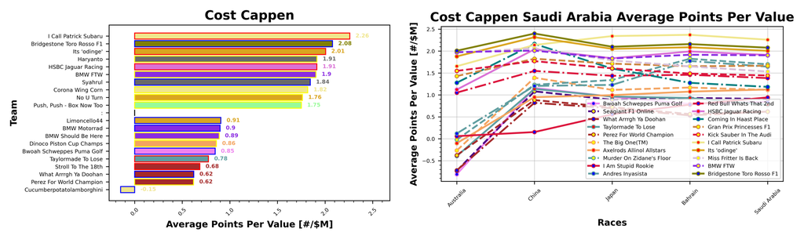

### Flavio Controls Every Millimeter

Leading the substitutions award at the moment is Stuart with Murder On Zidane's Floor with 17 subs so far, ahead of Chloe with Mickeys Roadster Racers on 16, and Stefanus and Syahrul with 15. None of these teams have been hit with penalties yet.

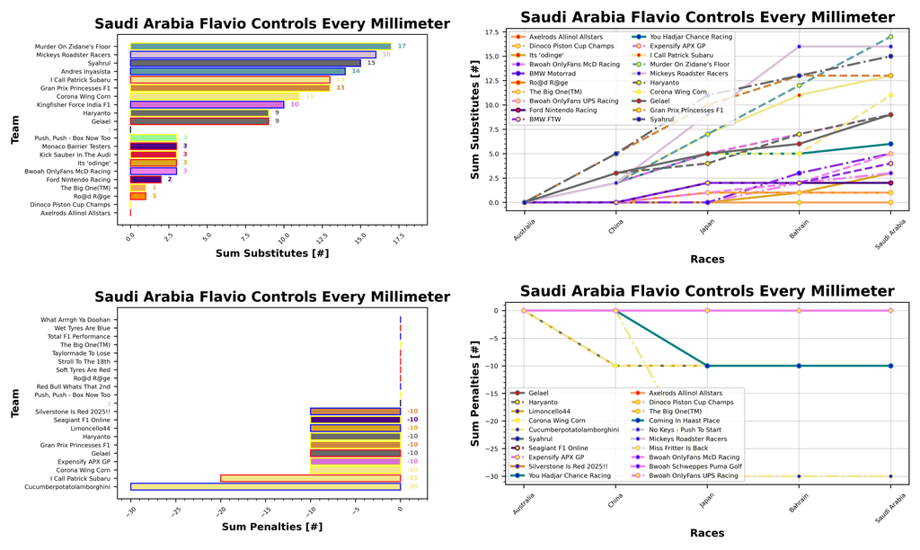

### Mega Driver

With only one use of the Extra DRS token so far, the prize is currently lead by Alfie. Check back later!

### Sprint King

Obviously no change to the Sprint King award this week. It's still Josh with HSBC Jaguar Racing out front with 283 points ahead of Sebastian and Bridgestone Toro Rosso F1 with 277 and Madlen with Push, Push - Box Now Too with 276.

```
No images found for Sprint King for Saudi Arabia.
```

### The Continental

More To Come.

[output not shown]

### The Triple Header

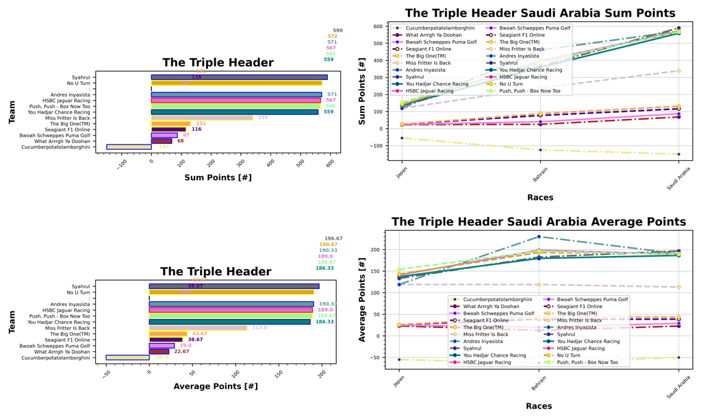

### I Forgot I Was Taking Part

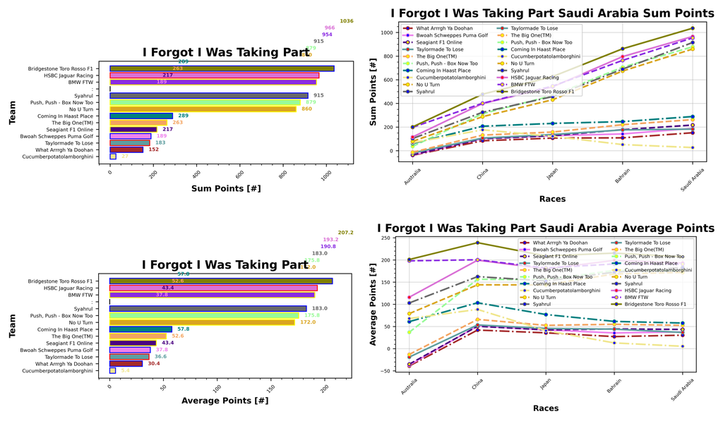

### Zak's Master Plan

Check back after the season break!

## F1 Predict

Josh took the victory this week with 85 points (37% correct) ahead of Phil with 55 (53%) and Pierce with 50 points (43%). Matty scored 45 points this week with 43% correct, ahead of Val with 40 points (33%). Stuart scored 0 this week.

That means Pierce leads the way with 248 points (45%) ahead of Josh with 245 points (25%). Stuart is in third place with 222 (50%), and Phil is in fourth with 216 points (46%). Val is in fifth with 155 points (44%) and Matty rounds out the league with 95 points (43%).

## Next Up

Next up, F1 lands in Miami for what is set to be the cringe Grand Prix of the year. It's a sprint weekend so plenty of points on offer! Best of luck to you all.